# 14.Cluster_Q slides

## Cluster

### Da-Wei Chiang

## 大綱

- 何謂分群
- 何謂相似
- `Hierarchical Methods`
- `Hierarchical Implement`
- `K-Means`
- `K-Means Implement`
- `Cluster Evaluate`
- `Cluster Evaluate Implement`
- 如何找到最佳的`K`

## 何謂分群

[figure not shown]

## 何謂分群

[figure not shown]

## 何謂分群

[figure not shown]

## 何謂分群

[figure not shown]

## 何謂分群

- 讓資料說話, 由資料自行分群
  - 將相似的資料歸為一群

## 何謂相似

- 歐式距離`(Euclidean Distance)`
- 曼哈頓距離`(Manhattan Distance)`
- 謝比雪夫距離`(Chebyshev Distance)`

## `Hierarchical Methods`

- `Single Link`
  - 取最小距離

## `Single Link Example`

| ID | Age | Salary |  |
| --- | --- | --- | --- |
| 1 | 42 | 0.18 |  |
| 2 | 36 | 0.44 |  |
| 3 | 18 | 0.36 |  |
| 4 | 50 | 0.38 |  |
| 5 | 38 | 0.52 |  |

## 使用歐式距離產生`Distance Matrix`

| ID | 1 | 2 | 3 | 4 | 5 |  |
| --- | --- | --- | --- | --- | --- | --- |
| 1 | 0 | 6 | 24 | 8 | 4 |  |
| 2 | 6 | 0 | 18 | 14 | 2 |  |
| 3 | 24 | 18 | 0 | 32 | 20 |  |
| 4 | 8 | 14 | 32 | 0 | 12 |  |
| 5 | 4 | 2 | 20 | 12 | 0 |  |

## 產生第一筆 `Link`

- 找出最短距離產生第一筆`Link`
  - 最短距離為`2（ID2, ID5）`

[figure not shown]

## `Calc Distance`

- 找出各點與`ID2、ID5`最短距離
  - `Min(dist(ID2, ID1), dist(ID5, ID1)) = Min(6, 4) = 4`
  - `Min(dist(ID2, ID3), dist(ID5, ID3)) = Min(18, 20) = 18`
  - `Min(dist(ID2, ID4), dist(ID5, ID4)) = Min(14, 12) = 12`

## `Update Distance`

| ID | 1 | 2、5 | 3 | 4 |  |
| --- | --- | --- | --- | --- | --- |
| 1 | 0 | 4 | 24 | 8 |  |
| 2、5 | 4 | 0 | 18 | 12 |  |
| 3 | 24 | 18 | 0 | 32 |  |
| 4 | 8 | 12 | 32 | 0 |  |

## 產生第二筆 `Link`

- 找出最短距離產生第二筆`Link`
  - 最短距離為`4（ID25, ID1）`

[figure not shown]

## `Calc Distance`

- 找出各點與`ID25、ID1`最短距離
  - `Min(dist(ID25, ID3), dist(ID1, ID3)) = Min(18, 24) = 18`
  - `Min(dist(ID25, ID4), dist(ID1, ID4)) = Min(12, 8) = 8`

## `Update Distance`

| ID | 2、5、1 | 3 | 4 |  |
| --- | --- | --- | --- | --- |
| 2、5、1 | 0 | 18 | 8 |  |
| 3 | 18 | 0 | 32 |  |
| 4 | 8 | 32 | 0 |  |

## 產生第三筆 `Link`

- 找出最短距離產生第三筆`Link`
  - 最短距離為`8（ID251, ID4）`

[figure not shown]

## `Calc Distance`

- 找出各點與`ID251、ID4`最短距離
  - `Min(dist(ID251, ID3), dist(ID4, ID3)) = Min(18, 32) = 18`

## `Update Distance`

| ID | 2、5、1、4 | 3 |  |
| --- | --- | --- | --- |
| 2、5、1、4 | 0 | 18 |  |
| 3 | 18 | 0 |  |

## 產生第四筆 `Link`

[figure not shown]

## 理論練習

- 有個資料及如下, 請使用`Hierarchical Single Link`進行分群

| Math Score | English Score |  |
| --- | --- | --- |
| 72 | 80 |  |
| 90 | 78 |  |
| 88 | 92 |  |
| 66 | 100 |  |
| 98 | 66 |  |

## `Hierarchical Implement`

- `SKLearn`
- `Scipy`

## `SKLearn`

```
from sklearn.cluster import AgglomerativeClustering

AgglomerativeClustering(n_clusters=3,linkage='single')

#參數說明
n_clusters : 欲分群群數
linkage : 計算群聚的方式(ward, complete, average, single)
```

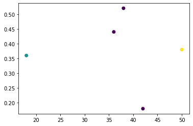

```
[0 0 1 2 0]
```

```python
## 範例

from sklearn.cluster import AgglomerativeClustering
from matplotlib import pyplot as plt
import numpy as np

X = np.array([[42,0.18],
    [36,0.44],
    [18,0.36],
    [50,0.38],
    [38,0.52]])

linked = AgglomerativeClustering(n_clusters=3,linkage='single')

linked.fit_predict(X)
plt.scatter(X[:,0],X[:,1],c=linked.fit_predict(X))
plt.show()
print(linked.fit_predict(X))
```

## `Scipy`

```
from scipy.cluster.hierarchy import dendrogram    #引用繪製群圖
from scipy.cluster.hierarchy import linkage       #引用階層分群法
from scipy.cluster.hierarchy import fcluster      #呈現所屬群數


Hierarchical_Variable = linkage(Data, method)  #創建分群

dendrogram(Hierarchical_Variable)  #群圖

fcluster(Hierarchical_Variable, k, criterion='maxclust')    #計算所屬群數

#參數說明
method : 計算群聚的方式(single, complete, average, weighted, centroid, median, ward)
k : 欲分群群數
```

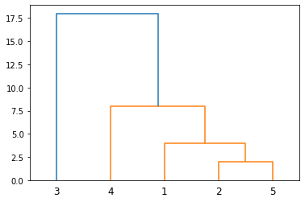

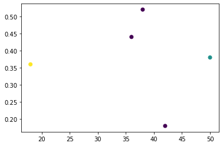

```
[1 1 3 2 1]
```

```python
## 範例

from scipy.cluster.hierarchy import dendrogram, linkage, fcluster
from matplotlib import pyplot as plt
import numpy as np

X = np.array([[42,0.18],
    [36,0.44],
    [18,0.36],
    [50,0.38],
    [38,0.52],])

linked = linkage(X, 'single')

label = range(1, 6)
dendrogram(linked, labels=label)
plt.show()
clusters = fcluster(linked,3,criterion='maxclust')
plt.scatter(X[:,0],X[:,1],c=clusters)
plt.show()
print(clusters)
```

## 練習

- 承上題, 使用上題理論練習的假資料集進行`Implement`練習

## `K-Means`

## `K-Means 步驟`

- `Step 1:` 指定預分群群數k
- `Step 2:` 於資料中隨機產生k個點
- `Step 3:` 計算每一個資料點到k個群心的距離
- `Step 4:` 將資料點歸為距離最近的那個群心
- `Step 5:` 更新群心（`Step 4 這些資料點的平均值作為新的群心`）
- `Step 6:` 不斷重複`Step 3 ~ Step 5`直到更新的群心與上一次群心相同

## `Step 1 : 指定 K = 3`

## `Step 2`

[figure not shown]

```python
## Step 3

from scipy.spatial import distance #引用歐式距離函數
import numpy as np

X = np.array([[42,0.18],
    [36,0.44],
    [18,0.36],
    [50,0.38],
    [38,0.52],])
diamond = np.array((20, 0.45))   #菱形
pentagon = np.array((35, 0.35))  #五邊形
triangle = np.array((45, 0.45))  #三角形
for i in range(5):
    print(X[i, :])
    print("菱形 :", distance.euclidean(diamond, X[i, :]))
    print("五邊形 :",distance.euclidean(pentagon, X[i, :]))
    print("三角形 :",distance.euclidean(triangle, X[i, :]))
    print("- - - - - -")
```

```
[42.    0.18]
菱形 : 22.001656755799097
五邊形 : 7.002063981427191
三角形 : 3.0121254953935765
- - - - - -
[36.    0.44]
菱形 : 16.000003124999694
五邊形 : 1.004041831797859
三角形 : 9.000005555553841
- - - - - -
[18.    0.36]
菱形 : 2.002023975880409
五邊形 : 17.000002941176216
三角形 : 27.000149999583336
- - - - - -
[50.    0.38]
菱形 : 30.00008166655551
五邊形 : 15.00002999997
三角形 : 5.000489975992353
- - - - - -
[38.    0.52]
菱形 : 18.000136110596497
五邊形 : 3.0048128061494945
三角形 : 7.000349991250437
- - - - - -
```

## `Step 4`

[figure not shown]

```python
## Step 5
import numpy as np
diamond = np.array((18,0.36))
pentagon = np.array(((36+38)/2, (0.44+0.52)/2))
triangle = np.array(((42+50)/2, (0.18+0.38)/2))
print("菱形 :", diamond)
print("五邊形 :", pentagon)
print("三角形 :", triangle)
```

```
菱形 : [18.    0.36]
五邊形 : [37.    0.48]
三角形 : [46.    0.28]
```

## `Step 5`

[figure not shown]

```python
## Step 6 重複 Step 3

from scipy.spatial import distance
import numpy as np

X = np.array([[42,0.18],
    [36,0.44],
    [18,0.36],
    [50,0.38],
    [38,0.52],])
diamond = np.array((18, 0.36))   #菱形
pentagon = np.array((37, 0.48))  #五邊形
triangle = np.array((46, 0.28))  #三角形
for i in range(5):
    print(X[i, :])
    print("菱形 :", distance.euclidean(diamond, X[i, :]))
    print("五邊形 :",distance.euclidean(pentagon, X[i, :]))
    print("三角形 :",distance.euclidean(triangle, X[i, :]))
    print("- - - - - -")

## 該結果資料歸類與上次相同, 故完成KMeans
```

```
[42.    0.18]
菱形 : 24.00067499050808
五邊形 : 5.008991914547278
三角形 : 4.001249804748511
- - - - - -
[36.    0.44]
菱形 : 18.00017777689987
五邊形 : 1.0007996802557444
三角形 : 10.001279918090484
- - - - - -
[18.    0.36]
菱形 : 0.0
五邊形 : 19.00037894358952
三角形 : 28.00011428548105
- - - - - -
[50.    0.38]
菱形 : 32.00000624999939
五邊形 : 13.000384609695207
三角形 : 4.001249804748511
- - - - - -
[38.    0.52]
菱形 : 20.000639989760327
五邊形 : 1.0007996802557444
三角形 : 8.003599190364294
- - - - - -
```

## 該例KMeans最終結果

[figure not shown]

## 理論練習

- 有個資料及如下, 請使用`KMeans`進行分群

| Math Score | English Score |  |
| --- | --- | --- |
| 72 | 80 |  |
| 90 | 78 |  |
| 88 | 92 |  |
| 66 | 100 |  |
| 98 | 66 |  |

## `K-Means Implement`

```
from sklearn import cluster #引用

cluster.KMeans(n_clusters, n_init)

#參數說明
n_clusters: 分群數
n_init: 初始點數隨機產生幾次運算
```

```
[1 2 0 1 2]
```

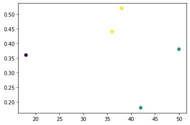

```python
## 範例

from sklearn import cluster

X = np.array([[42,0.18],
    [36,0.44],
    [18,0.36],
    [50,0.38],
    [38,0.52],])
kmeans_fit = cluster.KMeans(n_clusters = 3, n_init = 1).fit_predict(X)
print(kmeans_fit)
plt.scatter(X[:,0],X[:,1],c=kmeans_fit)
plt.show()
```

## 練習

- [Gender data](https://drive.google.com/file/d/1qMuXBXD5XCV1EBRfvndNVbtzXrgkeW-P/view?usp=sharing)
- 請使用該資料及進行`KMeans`分群

## `Cluster Evaluate`

- 輪廓係數法`(Silhouette Coefficient)`
  - 群內差異越小, 群外差異越大
  - 越接近1越好，反之越接近-1越差

## `Cluster Evaluate Implement`

```
from sklearn import metrics  #引用

silhouette_Variable = metrics.silhouette_score(DataSet, Cluster_Label)
```

```python
## 範例

from sklearn import cluster
from sklearn import metrics

X = np.array([[42,0.18],
    [36,0.44],
    [18,0.36],
    [50,0.38],
    [38,0.52],])
kmeans_fit = cluster.KMeans(n_clusters = 3, n_init = 10).fit_predict(X)
print(kmeans_fit)
silhouette = metrics.silhouette_score(X, kmeans_fit)
print(silhouette)
```

```
[1 1 2 0 1]
0.3674643473853353
```

## 練習

- 承上題練習, 請評估[Gender data](https://drive.google.com/file/d/1qMuXBXD5XCV1EBRfvndNVbtzXrgkeW-P/view?usp=sharing)資料集的分群狀況

## 請問如何找到最佳的`K`？

## 練習

- 請使用`make_blobs`產生100筆資料, 該資料有兩個欄位四個類別、標準差為1
- 試著找出最佳的k值, 並畫出最佳k值的散步圖與產生資料的類型進行比較

## 作業

- 請各位在不使用`sklearn Cluster model`的情況下撰寫`K-Means`演算法